# Challenge 2: Spicing things up with ggplot2

Author

Sylvia Du!

For this week’s Challenge, you will have three different options to explore. I’ve arranged these options in terms of their “spiciness,” or the difficulty of completing the task. **You are only required to complete one task, but if you are interested in exploring more than one, feel free!**

This is a great place to let your creativity show! Make sure to indicate what additional touches you added, and provide any online references you used.

# Getting Set-up

Within this document, make sure to specify that your plots are contained in your document (`self-contained: true`) and that your code is visible to the reader (`echo: true`). If there are other formatting specifics you would like to include, feel free to toss those in the YAML, too!

Next, create a setup code chunk to load the packages and read in the `surveys.csv` data file exactly how you did in Lab 2.

```r
library(tidyverse)
library(here)
surveys <- read_csv("data/surveys.csv")
#https://www.rdocumentation.org/packages/dplyr/versions/1.0.10/topics/glimpse
glimpse(surveys)
```

```
Rows: 30,463
Columns: 15
$ record_id       <dbl> 63, 64, 65, 66, 67, 68, 69, 71, 74, 75, 78, 79, 81, 82…
$ month           <dbl> 8, 8, 8, 8, 8, 8, 8, 8, 8, 8, 8, 8, 8, 8, 8, 8, 8, 8, …
$ day             <dbl> 19, 19, 19, 19, 19, 19, 19, 19, 19, 19, 19, 19, 19, 19…
$ year            <dbl> 1977, 1977, 1977, 1977, 1977, 1977, 1977, 1977, 1977, …
$ plot_id         <dbl> 3, 7, 4, 4, 7, 8, 2, 7, 8, 8, 1, 7, 4, 4, 6, 19, 23, 1…
$ species_id      <chr> "DM", "DM", "DM", "DM", "DM", "DO", "PF", "DM", "PF", …
$ sex             <chr> "M", "M", "F", "F", "M", "F", "M", "F", "M", "F", "M",…
$ hindfoot_length <dbl> 35, 37, 34, 35, 35, 32, 15, 36, 12, 32, 16, 34, 14, 35…
$ weight          <dbl> 40, 48, 29, 46, 36, 52, 8, 35, 7, 22, 9, 42, 8, 41, 37…
$ date            <date> 1977-08-19, 1977-08-19, 1977-08-19, 1977-08-19, 1977-…
$ day_of_week     <chr> "Fri", "Fri", "Fri", "Fri", "Fri", "Fri", "Fri", "Fri"…
$ plot_type       <chr> "Long-term Krat Exclosure", "Rodent Exclosure", "Contr…
$ genus           <chr> "Dipodomys", "Dipodomys", "Dipodomys", "Dipodomys", "D…
$ species         <chr> "merriami", "merriami", "merriami", "merriami", "merri…
$ taxa            <chr> "Rodent", "Rodent", "Rodent", "Rodent", "Rodent", "Rod…
```

Finally, create another code chunk and paste in your code from Question 14 or Question 15 in Lab 2 – we will be modifying the box plot of weights by species!

# Medium: Ridge Plots

In Lab 2, you used side-by-side **boxplots** to visualize the distribution of weight within each species of rodent. Boxplots have [substantial flaws](https://www.data-to-viz.com/caveat/boxplot.html), namely that they disguise distributions with multiple modes.

A “superior” alternative is the density plot. However, `ggplot2` does not allow for side-by-side density plots using `geom_density()`. Instead, we will need to make use of the `ggridges` package to create side-by-side density (ridge) plots.

> **For this challenge you are to change your boxplots to ridge plots. You will need to install the `ggridges` package and explore the `geom_density_ridges()` function.**

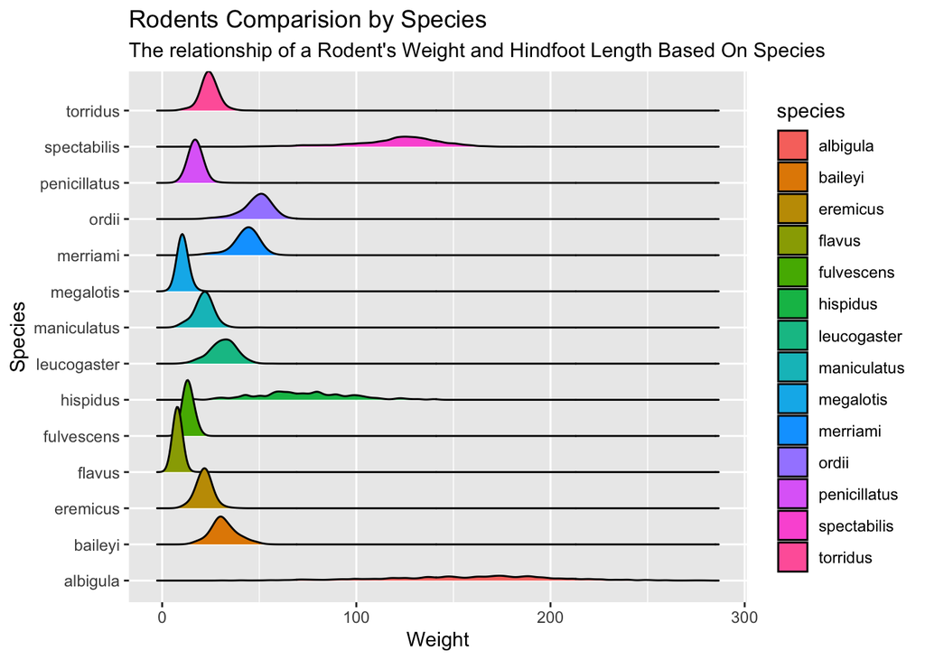

```r
library(ggridges)

ggplot(data = surveys,
       mapping = aes(
         x = weight,
         y = species,
         fill = species
         )
      ) +
  #https://r-graph-gallery.com/294-basic-ridgeline-plot.html for ridgeplot reference
  geom_density_ridges() +
  labs(x = "Weight",
       y = "Species",
       title = "Rodents Comparision by Species",
       subtitle = "The relationship of a Rodent's Weight and Hindfoot Length Based On Species")
```

# Spicy: Exploring Color Themes

The built-in `ggplot()` color scheme may not include the colors you were looking for. Don’t worry – there are many other color palettes available to use!

You can change the colors used by `ggplot()` in a few different ways.

### Manual Specification

Add the `scale_color_manual()` or `scale_fill_manual()` functions to your plot and directly specify the colors you want to use. You can either:

1. define a vector of colors within the `scale` functions (e.g. `values = c("blue", "black", "red", "green")`) OR
2. create a vector of colors using hex numbers and store that vector as a variable. Then, call that vector in the `scale_color_manual()` function.

Here are some exaplme hex color schemes:

```r
# A vector of a RG color deficient friendly palette with gray:
cdPalette_grey <- c("#999999", "#E69F00", "#56B4E9", "#009E73", "#F0E442", "#0072B2", "#D55E00", "#CC79A7")

# A vector of a RG color deficient friendly palette with black:
cdPalette_blk <- c("#000000", "#E69F00", "#56B4E9", "#009E73", "#F0E442", "#0072B2", "#D55E00", "#CC79A7")
```

**Note**

If you are interested in using specific hex colors, I like the [image color picker app](https://imagecolorpicker.com/en) to find the colors I want.

### Package Specification

While manual specification may be necessary for some contexts, it can be a real pain to handpick 5+ colors. This is where color scales built-in to R packages come in handy! Popular packages for colors include:

- `RColorBrewer` – change colors by using `scale_fill_brewer()` or `scale_colour_brewer()`.
- `viridis` – change colors by using `scale_colour_viridis_d()` for discrete data, `scale_colour_viridis_c()` for continuous data.
- `ggsci` – change colors by using `scale_color_<PALNAME>()` or `scale_fill_<PALNAME>()`, where you specify the name of the palette you wish to use (e.g. `scale_color_aaas()`).

**Note**

[This website](https://github.com/EmilHvitfeldt/r-color-palettes) provides an exhaustive list of color themes available through various packages.

> **In this challenge you are expected to use this information to modify the boxplots you created Lab 2. First, you are to color the boxplots based on the variable `genus`. Next, you are to change the colors used for `genus` using either manual color specification or any of the packages listed here (or others!).**

# Hot: Exploring `ggplot2` Annotation

Some data scientists advocate that we should try to eliminate legends from our plots to make them more clear. Instead of using legends, which cause the reader’s eye to stray from the plot, we should use **annotation**.

We can add annotation(s) to a `ggplot()` using the `annotate()` function:

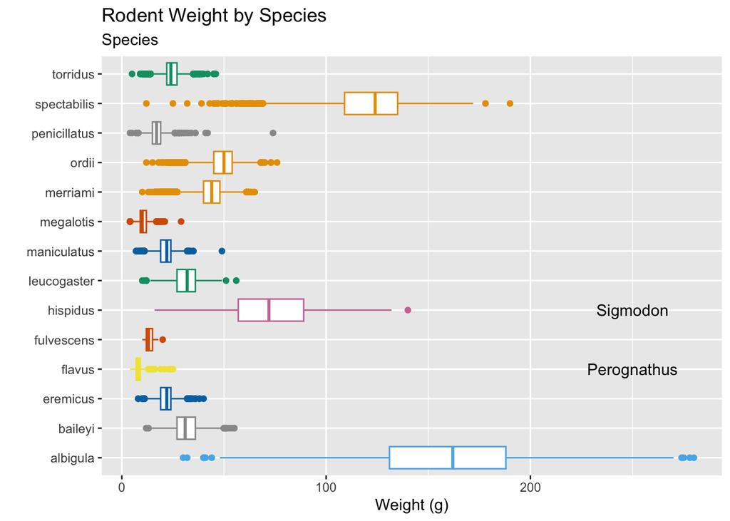

```r
ggplot(data = surveys,
       mapping = aes(y = species,
                     x = weight,
                     color = genus)) +
  geom_boxplot() +
  scale_color_manual(values = cdPalette_grey) +
  annotate("text", y = 6, x = 250, label = "Sigmodon") +
  annotate("text", y = 4, x = 250, label = "Perognathus") +
  theme(legend.position = "none") +
  labs(x = "Weight (g)",
       y = "",
       subtitle = "Species",
       title = "Rodent Weight by Species")
```

Note that I’ve labeled the “Sigmodon” and “Perognathus” genera, so the reader can tell that these boxplots are associated with their respective genus.

> **In this challenge you are expected to use this information to modify the boxplots you created in Lab 2. First, you are to color the boxplots based on the variable `genus`. Next, you are to add annotations for each genus next to the boxplot(s) associated with that genus. Finally, you are expected to use the `theme()` function to remove the color legend from the plot, since it is no longer needed!**

# Challenge 2 Submission

Once you have completed your challenge(s) you should upload your rendered HTML file to Canvas.

Your Challenge 2 file **must** be separate from your Lab 2 file. Yes, some of the code for the Challenge is the same as Lab 2 – you can copy and paste this code into a **new** Quarto file. Your Challenge 2 submission should only included code necessary for completing the Challenge, nothing else.

Similar to Lab 2, you should submit **only** your HTML file. Your HTML file is required to have the following specifications in the YAML options (at the top of your document):

- have the plots embedded (`embed-resources: true`)
- include your source code (`code-tools: true`)
- include all your code and output (`echo: true`)

**If any of the options are not included, your assignment will receive an “Incomplete” and you will be required to submit a revision.**

In addition, your document should not have any warnings or messages output in your HTML document. **If your HTML contains warnings or messages, you will receive an “Incomplete” for document formatting and you will be required to submit a revision.**